[figure not shown]

# Multiscale Cross-Entropy: XMSEn()

Table of Contents

Syntax: References: About XMSEn(): The 'RadNew' Argument: Note: Example 1: Example 2: Example 3: Example 4:

#### Syntax:

[MSx, Ci] = XMSEn(Sig, 'Scales', 3, 'Methodx', 'coarse', 'RadNew', 0, 'Plotx', false)

- Sig Time series signals, a N x 2 matrix where N > 10.
- Scales Number of grained time scales, a positive integer.
- Methodx Type of graining method, one of the following strings: "coarse" / "modified" / "timeshift" / "imf" [See the EntropyHub Guide for more info on signal graining procedures.]
- RadNew Radius rescaling method, an integer in the range [0 4]. When the Base entropy method speci ed by Mobj is XSampEn or XApEn, RadNew allows the radius threshold to be updated based on the grained signal at each time scale (). If a radius threshold value (r) is speci ed in Mobj, this becomes the rescaling coefficient, otherwise it is set to 0.2 (default). The value of RadNew speci es one of the following methods: 0 - no rescaling / 1 - Standard Deviation / 2 - Variance / 3 - Mean Absolute Deviation / 4 - Median Absolute Deviation
- Plotx A plot of the multiscale entropy curve: true - Plots time scale vs entropy value / false - No plot.
- MSx Multiscale cross-entropy estimate at each time scale, a vector of length Scales.
- Ci Complexity index (area under the multiscale entropy curve), a scalar.

#### References:

1. Madalena Costa, Ary Goldberger, and C-K. Peng, Multiscale entropy analysis of complex physiologic time series, Physical review letters 89.6 (2002): 068102.
2. Vadim V. Nikulin, and Tom Brismar, Comment on "Multiscale entropy analysis of complex physiologic time series", Physical review letters 92.8 (2004): 089803.
3. Madalena Costa, Ary L. Goldberger, and C-K. Peng. Costa, Goldberger, and Peng reply, Physical Review Letters 92.8 (2004): 089804.
4. Antoine Jamin, et al, A novel multiscale cross-entropy method applied to navigation data acquired with a bike simulator, 41st annual international conference of the IEEE EMBC, 2019.
5. Antoine Jamin and Anne Humeau-Heurtier, (Multiscale) Cross-Entropy Methods: A Review, Entropy 22.1 (2020): 45.
6. Rui Yan, Zhuo Yang, and Tao Zhang, Multiscale cross entropy: a novel algorithm for analyzing two time series, 5th International Conference on Natural Computation, Vol. 1, pp: 411-413 IEEE, 2009.
7. Yi Yin, Pengjian Shang, and Guochen Feng, Modified multiscale cross-sample entropy for complex time series, Applied Mathematics and Computation 289 (2016): 98-110.

#### About XMSEn():

To use the multiscale cross-entropy function (XMSEn), one must first create a multiscale entropy object using MSobject() to specify the type of entropy and its parameters used in the multiscale cross-entropy estimation.

XMSEn() returns two results:

1. MSx the cross-entropy estimate at each time scale, a vector of length Scales
2. Ci the complexity index (area under the multiscale entropy curve), a scalar value

#### The 'RadNew' Argument:

Each multiscale cross-entropy function accepts a 'RadNew' name/value pair argument to perform radius distance threshold rescaling at each grained time-scale if the Cross entropy method specified by Mobj is XSampEn or XApEn.

If a radius threshold value (r) is specified in Mobj, RadNew becomes the rescaling coefficient, otherwise it is set to 0.2 (default). The value of RadNew specifies one of the following methods:

0 No rescaling

1 Standard deviation -

2 Variance -

3 Mean Abs Deviation -

4 Median Abs Deviation -

#### Note:

In the following examples, example signals / data are imported into MatLab using the ExampleData function from EntropyHub.

To use this function as outlined in the examples below, an internet connection is required.

ExampleData accepts any of the following strings:

- 'uniform2' uniformly distributed random numbers in range [0 1]
- 'gaussian2' normally distributed random numbers with mean = 0, and standard deviation = 1
- 'randintegers2' uniformly distributed pseudorandom integers in range [1 8]
- 'lorenz' X, Y, Z components of the Lorenz system (sigma: 10, beta: 8/3, rho: 28) [Xo = 10, Yo = 20, Zo = 10]
- 'henon' X, Y components of the Henon attractor (alpha: 1.4, beta: .3) [Xo = 0, Yo = 0]

#### Example 1:

Import two signals of uniformly distributed random numbers in the range [0,1] and create a multiscale entropy object with the following parameters:

```matlab
X = ExampleData('uniform2');
Mobj = MSobject('XApEn', 'm', 2, 'tau', 2, 'r', 0.4)
```

Mobj = struct with fields:

Func: @XApEn m: 2 tau: 2 r: 0.4000

Calculate the multiscale cross-approximate entropy over 3 coarse-grained temporal scales, where

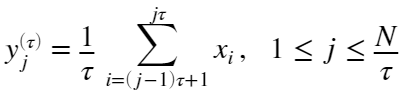

```matlab
MSx = XMSEn(X, Mobj)
```

. . . .

MSx = 1×3

0.4645 0.2034 0.1034

Calculate the multiscale cross-approximate entropy over 5 coarse-grained temporal scales instead.

```matlab
MSx = XMSEn(X, Mobj, 'Scales', 5)
```

. . . . . .

MSx = 1×5

0.4645 0.2034 0.1034 0.0540 0.0270

#### Example 2:

Import two signals of uniformly distributed pseudorandom integers in the range [1, 8] and create a multiscale entropy object with the following parameters:

EnType = XCondEn(), embedding dimension = 3, number of symbols = 6, normalization = true.

```matlab
X = ExampleData('randintegers2');
Mobj = MSobject('XCondEn', 'm', 3, 'c', 6, 'Norm', true)
```

Mobj = struct with fields:

Func: @XCondEn m: 3 c: 6 Norm: 1

Calculate the multiscale corrected cross-condtional entropy over 5 temporal scales using 'timeshift' graining procedure where

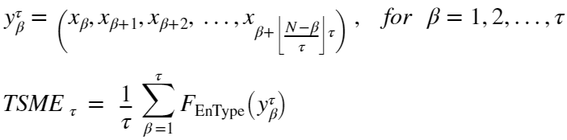

```matlab
MSx = XMSEn(X, Mobj, 'Scales', 5, 'Methodx', 'timeshift')
```

. . . . . . . . . . . . . . . . . . . . .

MSx = 1×5

0.9789 0.9688 0.9674 0.9686 0.9887

#### Example 3:

Import two signals of normally distributed random numbers [] and create a multiscale entropy object with the following parameters:

EnType = XSampEn(), embedding dimension = 4, radius distance threshold = 1.25

```matlab
X = ExampleData('gaussian2');
Mobj = MSobject('XSampEn', 'm', 4, 'r', 1.25)
```

Mobj = struct with fields:

Func: @XSampEn m: 4 r: 1.2500

Calculate the multiscale cross-sample entropy over 6 coarse-grained temporal scales where the radius distance threshold value (r) specified by Mobj becomes scaled by the standard deviation of the signals at each scale.

```matlab
MSx = XMSEn(X, Mobj, 'Scales', 6, 'RadNew', 1)
```

. . . . . . .

MSx = 1×6

0.4763 0.4702 0.4739 0.4502 0.4577 0.4622

Calculate the multiscale cross-sample entropy where the radius distance threshold value is scaled by the mean absolute deviation of the signals at each scale.

```matlab
MSx = XMSEn(X, Mobj, 'Scales', 6, 'RadNew', 3)
```

. . . . . . .

MSx = 1×6

0.6532 0.6525 0.6559 0.6267 0.6372 0.6352

#### Example 4:

Import the x and y components of the Henon system of equations and create a multiscale entropy object with the following parameters:

EnType = XFuzzEn(), embedding dimension = 4, time delay = 2, fuzzy function = 'gudermannian', fuzzy function parameter = 3, logarithm base = 10

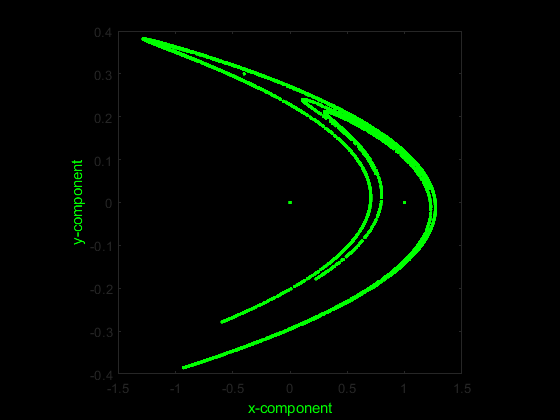

```matlab
Data = ExampleData('henon');
figure('Color', 'k')
plot(Data(:,1), Data(:,2), 'g.')
xlabel('x-component','color','g'), ylabel('y-component','color','g')
set(gca,'color','k'), axis square
```

```matlab
Mobj = MSobject('XFuzzEn', 'm', 4, 'tau', 2, 'Fx', 'gudermannian', 'r', 3, 'Logx', 10)
```

Mobj = struct with fields:

Func: @XFuzzEn m: 4 tau: 2 r: 3 Fx: 'gudermannian' Logx: 10

Calculate the multiscale cross-fuzzy entropy and complexity index of the x and y-components over 4 temporal scales where the grained signal at each scale is the cumulative sum of the intrinsic mode functions from the empirical mode decomposition of the original time series signals. Return a plot of the multiscale curve with the entropy estimates also.

. . . . .

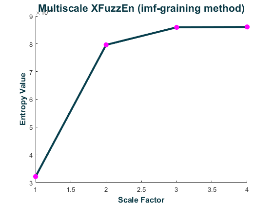

MSx = 1×4

10<sup>-3</sup> ×

0.3216 0.7964 0.8596 0.8610

Ci = 0.0028

```matlab
XY = Data(:,1:2);
[MSx, Ci] = XMSEn(XY, Mobj, 'Scales', 4, 'Methodx', 'imf', 'Plotx', true)
```